Neural Networks are widely applied algorithms that transfer the logic of biological neural systems to the domain of Data Science. Today a plethora of different types with varying applications are being developed, especially for classification tasks. Popular implementations encompass Natural Language Processing and the analysis of visual data.

However, as Neural Networks can also be used for regression problems, a *multilayer perceptron* or *feed-forward neural network* can be applied to predict a continuous target. The (fully connected) multilayer perceptron consists of an input layer with input neurons, in essence the features of a model, multiple hidden layers with varying numbers of neurons and an output layer. Within this construct all neurons are interconnected with the neurons of the next layer by different weights.

The outputs for every neuron are therefore the sum of the inputs that go into each node which are modified by a non-linear transformation, the *activation function*. As a common function for the modification of the inputs, the *sigmoid function* $\mathcal{y} = \frac1{1+e^{-z}}$ is applied. Furthermore, the output of the corresponding nodes are scaled by the connecting weights and then fed forward to the next layer of the network.

The training procedure of a multilayer perceptron involves the determination of the individual weights. This can be achieved using the gradient descent in the *backpropagation* (Rumelhart et al., 1986) algorithm to compute a (local or global) minimum of the error by successively updating the weights.

The following formulas are the basis for the algorithm:

*Error Formula*: $e=y_i-\hat{y}_{i}$,  
with $\hat{y}_{i}$ denoting the prediction of the i-th observation in the output layer

*Loss Function*: $\varepsilon=\frac12\sum_{i}(y_i-\hat{y}_{i})^2$

*Input Values*: $v_j=\sum_{i=0}^{m}w_{i,j}x_i$,  
with $x_i$ denoting the value of input $i$ at neuron $j$ and $w_{i,j}$ the synaptic weights of input $i$ at neuron $j$

*Function Signal*: $y_j=\varphi_j(v_j)$,  
with $\varphi_j$ denoting the activation function used at neuron $j$

Based on these formulas, it can be shown, that the weight adjustment is defined by:

*Weight Adjustment*: $\Delta w=-\eta\frac{\partial{\varepsilon}}{\partial{w_{i,j}}}$,  
with $\eta$ denoting the learning rate

In essence, the algorithm searches for weight adjustments that lead to decreasing loss. Additionally, the input data in the input layer are transformed using the min-max normalization to obtain data with in the interval [0, 1]. Due to better performance we opted for this data preprocessing method.

*Min-Max Normalization*: $z_i= \frac{x_i-Min(x)}{Max(x)-Min(x)}$

The following illustration might be useful to understand how the algorithm works:

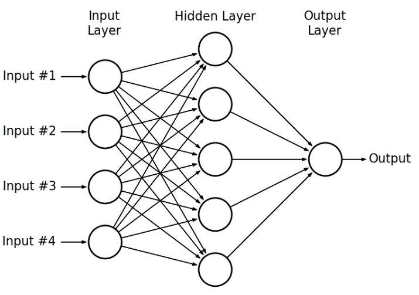

(Source: Hassan et al., 2015, p. 252)

*Sources*

- *Donald F. Specht, 1991, A General Regression Neural Network*
- *Zhang J.S., Xie X. T., 2011, Study about Forecasting of Vegetable Prices Based on Neural Network*
- *Hassan et al., 2015, Assessment of artificial neural network for bathymetry estimation using high resolution satellite imagery in shallow lakes: case study El Burullus lake* *Haykin Simon, 2009, Neural Networks and Learning Machines*
- *Crone et al., 2006, The Impact of Preprocessing on Support Vector Regression and Neural Networks in Time Series Prediction*